# DSSS2022 Machine Learning in R: Task List 02

Goran S. Milovanovic, DataKolektiv

[figure not shown]

# Data visualization in ggplot2

We will exercise our [ggplot2](https://ggplot2.tidyverse.org/) skills a bit here!

You may rely on [R for Data Science](https://r4ds.had.co.nz/), chapter [2 Data visualization](https://r4ds.had.co.nz/data-visualisation.html) to complete this exercise.

### ggplot2 in tidyverse

Load `tidyverse`:

```r
library(tidyverse)
```

### The dataset

We will use the same dataset as we have used in out Task List 1 for dplyr exercises: [Our World in Data - COVID-19 Data Explorer](https://ourworldindata.org/explorers/coronavirus-data-explorer):

- [Dataset GitHub repository](https://github.com/owid/covid-19-data/tree/master/public/data)
- [Dataset CSV file](https://covid.ourworldindata.org/data/owid-covid-data.csv)

based on:

> Mathieu, E., Ritchie, H., Ortiz-Ospina, E. et al. A global database of COVID-19 vaccinations. Nat Hum Behav (2021). https://doi.org/10.1038/s41562-021-01122-8.

We can access the `CSV` file directly from R’s `read.csv()`, as we have demonstrated in the classroom on Saturday, June 4:

```r
file_url <- "https://covid.ourworldindata.org/data/owid-covid-data.csv"
data_set <- read.csv(file_url,
                     header = TRUE,
                     check.names = FALSE,
                     stringsAsFactors = FALSE)
head(data_set)
```

|  | iso_code | continent | location | date | total_cases | new_cases | new_cases_smoothed | total_deaths | new_deaths | new_deaths_smoothed | total_cases_per_million | new_cases_per_million | new_cases_smoothed_per_million | total_deaths_per_million | new_deaths_per_million | new_deaths_smoothed_per_million | reproduction_rate | icu_patients | icu_patients_per_million | hosp_patients | hosp_patients_per_million | weekly_icu_admissions | weekly_icu_admissions_per_million | weekly_hosp_admissions | weekly_hosp_admissions_per_million | total_tests | new_tests | total_tests_per_thousand | new_tests_per_thousand | … |
| --- | --- | --- | --- | --- | --- | --- | --- | --- | --- | --- | --- | --- | --- | --- | --- | --- | --- | --- | --- | --- | --- | --- | --- | --- | --- | --- | --- | --- | --- | --- |
| 1 | AFG | Asia | Afghanistan | 2020-02-24 | 5 | 5 | NA | NA | NA | NA | 0.126 | 0.126 | NA | NA | NA | NA | NA | NA | NA | NA | NA | NA | NA | NA | NA | NA | NA | NA | NA | … |
| 2 | AFG | Asia | Afghanistan | 2020-02-25 | 5 | 0 | NA | NA | NA | NA | 0.126 | 0.000 | NA | NA | NA | NA | NA | NA | NA | NA | NA | NA | NA | NA | NA | NA | NA | NA | NA | … |
| 3 | AFG | Asia | Afghanistan | 2020-02-26 | 5 | 0 | NA | NA | NA | NA | 0.126 | 0.000 | NA | NA | NA | NA | NA | NA | NA | NA | NA | NA | NA | NA | NA | NA | NA | NA | NA | … |
| 4 | AFG | Asia | Afghanistan | 2020-02-27 | 5 | 0 | NA | NA | NA | NA | 0.126 | 0.000 | NA | NA | NA | NA | NA | NA | NA | NA | NA | NA | NA | NA | NA | NA | NA | NA | NA | … |
| 5 | AFG | Asia | Afghanistan | 2020-02-28 | 5 | 0 | NA | NA | NA | NA | 0.126 | 0.000 | NA | NA | NA | NA | NA | NA | NA | NA | NA | NA | NA | NA | NA | NA | NA | NA | NA | … |
| 6 | AFG | Asia | Afghanistan | 2020-02-29 | 5 | 0 | 0.714 | NA | NA | NA | 0.126 | 0.000 | 0.018 | NA | NA | NA | NA | NA | NA | NA | NA | NA | NA | NA | NA | NA | NA | NA | NA | … |

Let’s inspect the variables present here. **N.B.** A thorough description of the dataset is given in its [GitHub repo](https://github.com/owid/covid-19-data/tree/master/public/data).

```r
glimpse(data_set)
```

```
Rows: 192,072
Columns: 67
$ iso_code                                   <chr> "AFG", "AFG", "AFG", "AFG", "AFG", "AFG", "AFG", …
$ continent                                  <chr> "Asia", "Asia", "Asia", "Asia", "Asia", "Asia", "…
$ location                                   <chr> "Afghanistan", "Afghanistan", "Afghanistan", "Afg…
$ date                                       <chr> "2020-02-24", "2020-02-25", "2020-02-26", "2020-0…
$ total_cases                                <dbl> 5, 5, 5, 5, 5, 5, 5, 5, 5, 5, 5, 5, 8, 8, 8, 8, 1…
$ new_cases                                  <dbl> 5, 0, 0, 0, 0, 0, 0, 0, 0, 0, 0, 0, 3, 0, 0, 0, 3…
$ new_cases_smoothed                         <dbl> NA, NA, NA, NA, NA, 0.714, 0.714, 0.000, 0.000, 0…
$ total_deaths                               <dbl> NA, NA, NA, NA, NA, NA, NA, NA, NA, NA, NA, NA, N…
$ new_deaths                                 <dbl> NA, NA, NA, NA, NA, NA, NA, NA, NA, NA, NA, NA, N…
$ new_deaths_smoothed                        <dbl> NA, NA, NA, NA, NA, NA, NA, NA, NA, NA, NA, NA, N…
$ total_cases_per_million                    <dbl> 0.126, 0.126, 0.126, 0.126, 0.126, 0.126, 0.126, …
$ new_cases_per_million                      <dbl> 0.126, 0.000, 0.000, 0.000, 0.000, 0.000, 0.000, …
$ new_cases_smoothed_per_million             <dbl> NA, NA, NA, NA, NA, 0.018, 0.018, 0.000, 0.000, 0…
```

[output cut: 54 more lines]

Similarly as in our Task List 01, we need to remove everything where the `iso_code` begins with `^OWID_`:

```r
data_set <- data_set %>%
  filter(!str_detect(iso_code, "^OWID_"))
```

### Task 0.

Essentially, you do nothing in Task 0: just follow me as I add successive layers to a simple ggplot2 visualization. I would like to visualize the number of cases per year. First I need a data.frame for this visualization:

```r
data_set$year <- substr(data_set$date, 1, 4)
plot_frame <- data_set %>%
  select(new_cases, year) %>%
  group_by(year) %>%
  summarise(cases = sum(new_cases, na.rm = TRUE))
print(plot_frame)
```

| year | cases |
| --- | --- |
| 2020 | 82991259 |
| 2021 | 205192696 |
| 2022 | 242824316 |

Let’s define the visualization mapping in `aes()` and plot nothing, for the beginning:

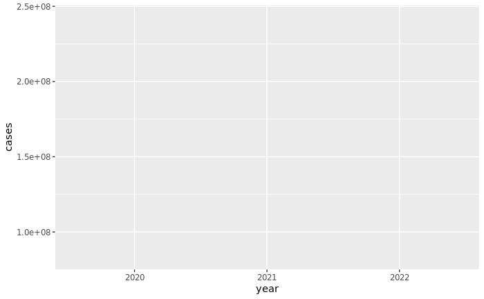

```r
ggplot(data = plot_frame,
       aes(x = year, y = cases))
```

Ok: ggplot2 recognizes my variables and their scales, but plots nothing. I need to add some geoms there for plot to materialize:

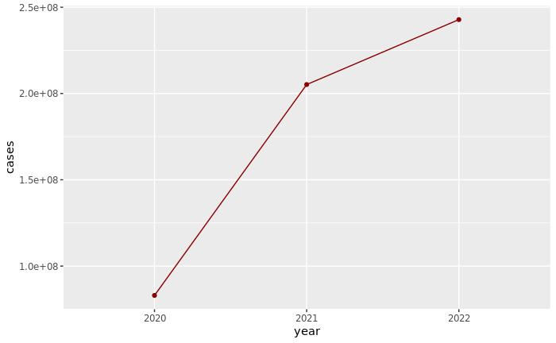

```r
ggplot(data = plot_frame,
       aes(x = year, y = cases)) +
  geom_point(size = 1.5, color = "darkred") +
  geom_path(group = 1, size = .5, color = "darkred")
```

I could have added a different geom:

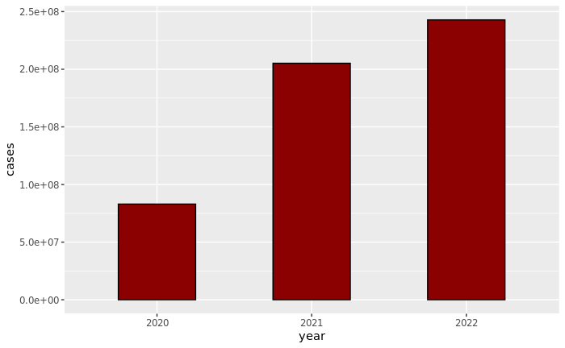

```r
ggplot(data = plot_frame,
       aes(x = year, y = cases)) +
  geom_bar(width = .5, stat = "identity", fill = "darkred", color = "black")
```

Now, what about `total_cases` per `month` and per `year`? I need a new `plot_frame` for this:

```r
data_set$year <- substr(data_set$date, 1, 4)
data_set$month <- as.character(substr(data_set$date, 6, 7))
plot_frame <- data_set %>%
  select(total_cases, year, month) %>%
  group_by(year, month) %>%
  summarise(cases = sum(total_cases, na.rm = TRUE))
print(plot_frame)
```

| year | month | cases |
| --- | --- | --- |
| 2020 | 01 | 38557 |
| 2020 | 02 | 1662085 |
| 2020 | 03 | 8955813 |
| 2020 | 04 | 63392483 |
| 2020 | 05 | 145000987 |
| 2020 | 06 | 246675251 |
| 2020 | 07 | 431559080 |
| 2020 | 08 | 671737999 |
| 2020 | 09 | 895044711 |
| 2020 | 10 | 1228857444 |

[output cut: 20 more lines]

Now:

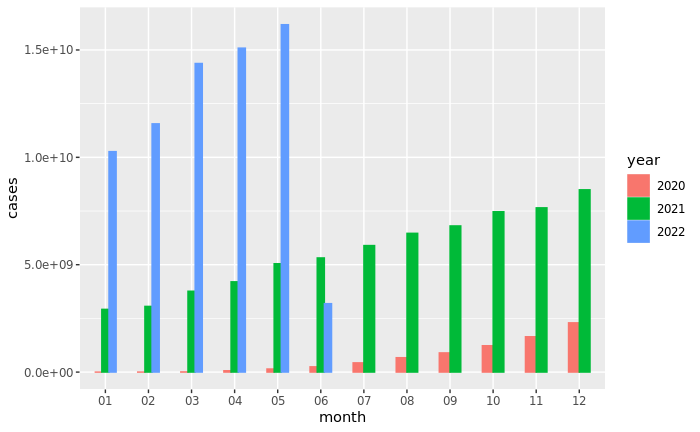

```r
ggplot(data = plot_frame,
       aes(x = month,
           y = cases,
           fill = year,
           color = year)) +
  geom_bar(width = .5,
           stat = "identity",
           position = position_dodge(width = 0.5))
```

Or I can do `facet_wrap`:

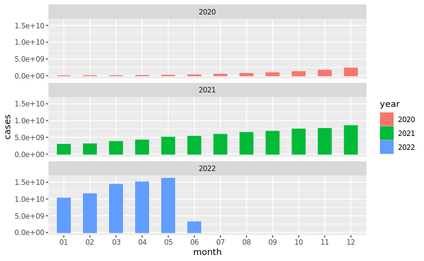

```r
ggplot(data = plot_frame,
       aes(x = month,
           y = cases,
           fill = year,
           color = year)) +
  geom_bar(width = .5,
           stat = "identity") +
  facet_wrap(~year, nrow = 3)
```

Now I can begin using `theme()` in order to style my chart.

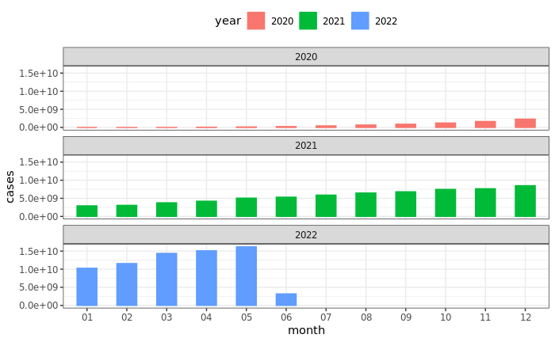

```r
ggplot(data = plot_frame,
       aes(x = month,
           y = cases,
           fill = year,
           color = year)) +
  geom_bar(width = .5,
           stat = "identity") +
  facet_wrap(~year, nrow = 3) +
  theme_bw() +
  theme(legend.position = "top")
```

Even better:

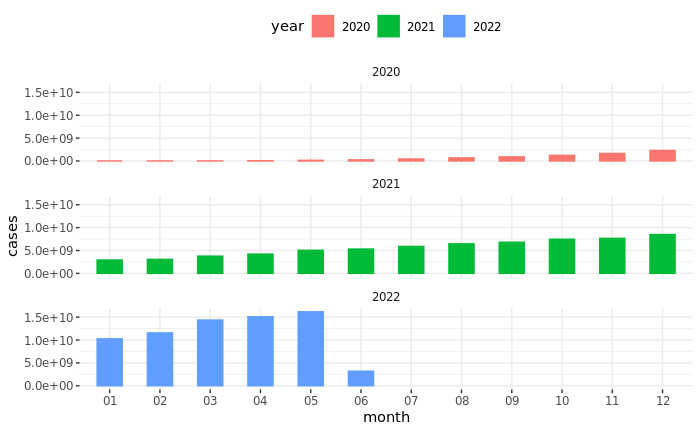

```r
ggplot(data = plot_frame,
       aes(x = month,
           y = cases,
           fill = year,
           color = year)) +
  geom_bar(width = .5,
           stat = "identity") +
  facet_wrap(~year, nrow = 3) +
  theme_bw() +
  theme(legend.position = "top") +
  theme(strip.background = element_rect(fill = "white", color = "white")) +
  theme(panel.border = element_blank())
```

If you want to avoid using the scientific notation on a scale (look at our y-axis), you can use the `scales` library:

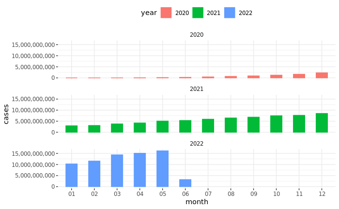

```r
# install.packages('scales')
library(scales)
ggplot(data = plot_frame,
       aes(x = month,
           y = cases,
           fill = year,
           color = year)) +
  geom_bar(width = .5,
           stat = "identity") +
  facet_wrap(~year, nrow = 3) +
  scale_y_continuous(labels = comma) +
  theme_bw() +
  theme(legend.position = "top") +
  theme(strip.background = element_rect(fill = "white", color = "white")) +
  theme(panel.border = element_blank())
```

Let’s now produce a scatter plot of the - mean number of `new_cases` per day, per country - and the country’s population (taking the latest available data).

Population first:

```r
population_set <- data_set %>%
  select(location, date, population) %>%
  arrange(location, date) %>%
  group_by(location) %>%
  slice_tail()
population_set
```

| location | date | population |
| --- | --- | --- |
| Afghanistan | 2022-06-06 | 39835428 |
| Albania | 2022-06-06 | 2872934 |
| Algeria | 2022-06-06 | 44616626 |
| Andorra | 2022-06-06 | 77354 |
| Angola | 2022-06-06 | 33933611 |
| Anguilla | 2022-06-06 | 15125 |
| Antigua and Barbuda | 2022-06-06 | 98728 |
| Argentina | 2022-06-06 | 45605823 |
| Armenia | 2022-06-06 | 2968128 |
| Aruba | 2022-06-06 | 107195 |

[output cut: 219 more lines]

```r
cases_set <- data_set %>%
  select(location, new_cases) %>%
  group_by(location) %>%
  summarise(mean_cases_per_day = mean(new_cases, na.rm = TRUE))
cases_set
```

| location | mean_cases_per_day |
| --- | --- |
| Afghanistan | 2.171827e+02 |
| Albania | 3.370915e+02 |
| Algeria | 3.192077e+02 |
| Andorra | 5.226578e+01 |
| Angola | 1.233140e+02 |
| Anguilla | 4.112360e+00 |
| Antigua and Barbuda | 1.029484e+01 |
| Argentina | 1.124439e+04 |
| Armenia | 5.108768e+02 |
| Aruba | 4.670972e+01 |

[output cut: 219 more lines]

Now I need to **join** `cases_set` to `population_set` by `locations`; if you are interested to learn about relational structures and join operations in `dplyr` in R, go read section [13 Relational data in R for Data Science](https://r4ds.had.co.nz/relational-data.html).

```r
plot_frame <- left_join(population_set,
                        cases_set,
                        by = "location")
plot_frame
```

| location | date | population | mean_cases_per_day |
| --- | --- | --- | --- |
| Afghanistan | 2022-06-06 | 39835428 | 2.171827e+02 |
| Albania | 2022-06-06 | 2872934 | 3.370915e+02 |
| Algeria | 2022-06-06 | 44616626 | 3.192077e+02 |
| Andorra | 2022-06-06 | 77354 | 5.226578e+01 |
| Angola | 2022-06-06 | 33933611 | 1.233140e+02 |
| Anguilla | 2022-06-06 | 15125 | 4.112360e+00 |
| Antigua and Barbuda | 2022-06-06 | 98728 | 1.029484e+01 |
| Argentina | 2022-06-06 | 45605823 | 1.124439e+04 |
| Armenia | 2022-06-06 | 2968128 | 5.108768e+02 |
| Aruba | 2022-06-06 | 107195 | 4.670972e+01 |

[output cut: 219 more lines]

Here goes our scatter plot:

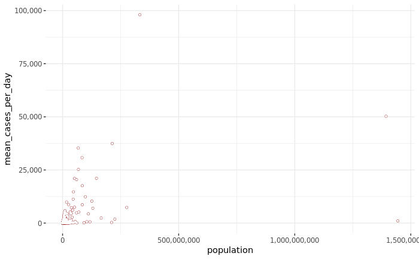

```r
ggplot(data = plot_frame,
       aes(x = population, y = mean_cases_per_day)) +
  geom_point(size = 1, color = "darkred") +
  geom_point(size = .75, color = "white") +
  scale_y_continuous(labels = comma) +
  scale_x_continuous(labels = comma) +
  theme_bw() +
  theme(panel.border = element_blank())
```

Maybe using `log()` scales?

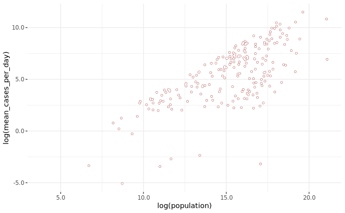

```r
ggplot(data = plot_frame,
       aes(x = log(population),
           y = log(mean_cases_per_day))) +
  geom_point(size = 1, color = "darkred") +
  geom_point(size = .75, color = "white") +
  scale_y_continuous(labels = comma) +
  scale_x_continuous(labels = comma) +
  theme_bw() +
  theme(panel.border = element_blank())
```

We can place the best fitting linear model on the chart by `geom_smooth(method="lm)`:

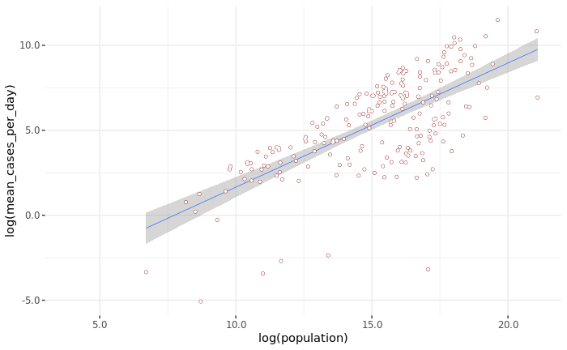

```r
ggplot(data = plot_frame,
       aes(x = log(population),
           y = log(mean_cases_per_day))) +
  geom_smooth(size = .25, method = "lm") +
  geom_point(size = 1, color = "darkred") +
  geom_point(size = .75, color = "white") +
  scale_y_continuous(labels = comma) +
  scale_x_continuous(labels = comma) +
  theme_bw() +
  theme(panel.border = element_blank())
```

### Task 1.

Reuse my code to produce a chart showing the

- the total number of `new_cases` per `continent` and per `year`.

### Task 2.

Reuse my code to produce a scatter plot of:

- the mean `gdp_per_capita` per country, and
- the country `population_density`.

[figure not shown]

**Data Science Summer School 2022**  
**Machine Learning in R**  
DataKolektiv, Belgrade, June 2022.